# decontam threshold comparison

Prevalence, frequency, and combined methods on the unfiltered DT_Swab **v3** phyloseq object. Thresholds increase from 0.1 to 0.7 in 0.1 steps.

Generated 2026-09-18 16:25:26 KST | decontam 1.30.0 | direct `decontam::isContaminant()` calls

**55**samples

**2,108**ASVs before decontam filtering

**5**negative controls

**8.2%**concentration CV

**At threshold 0.1:** prevalence flagged 61 ASVs, frequency flagged 1, and combined flagged 34. Combined removed 57.9% of negative-control reads while removing 3.1% of biological-sample reads.

**Frequency caution:** the supplied original-QC concentrations span only 0.40-0.56 ng/uL (CV 8.2%). The method runs correctly, but this narrow range limits frequency-based discrimination and explains the unstable jump at higher thresholds.

## Methods compared

### Prevalence

Uses presence/absence differences between 50 biological samples and 5 negative controls.

### Frequency

Uses the inverse relationship between feature frequency and DNA concentration.

### Combined

Combines prevalence and frequency evidence using decontam's documented combined method.

## Threshold sensitivity

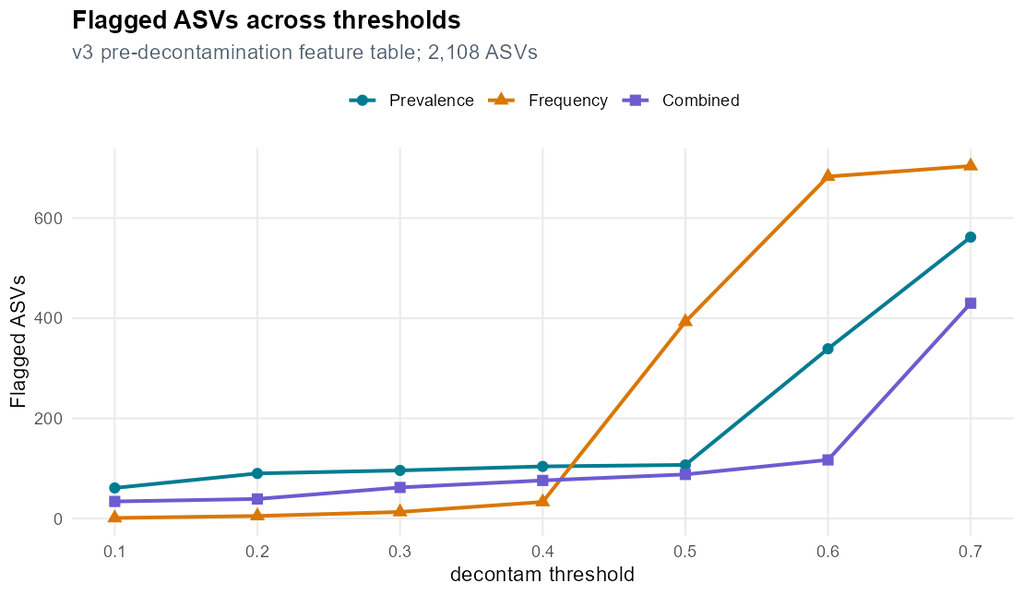

The decision boundary changes most sharply for prevalence at 0.6 and for frequency at 0.5-0.6.

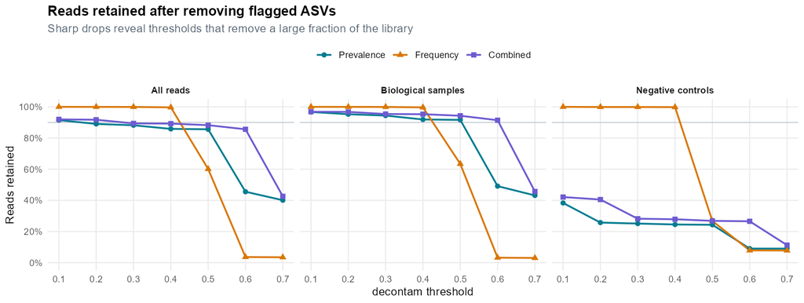

A useful threshold should preferentially remove control reads without collapsing biological reads.

## Method agreement

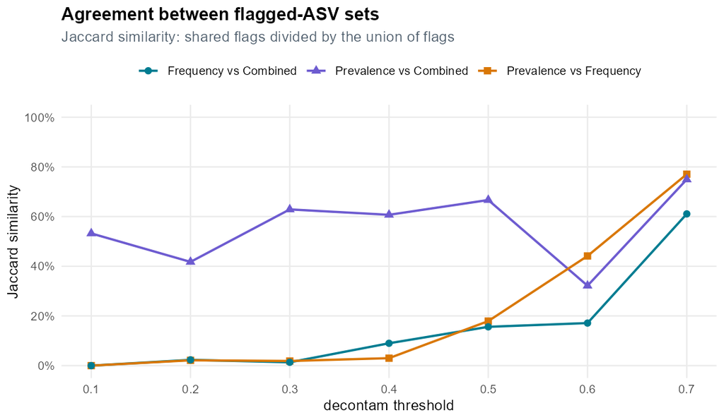

Low agreement is expected when frequency has little concentration contrast; combined is not simply the union of the two classifications.

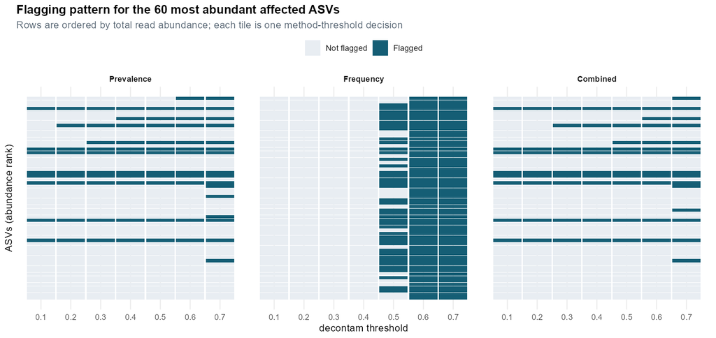

The heatmap exposes which abundant ASVs become flagged only after more permissive thresholds are used.

## Taxonomy of flagged reads

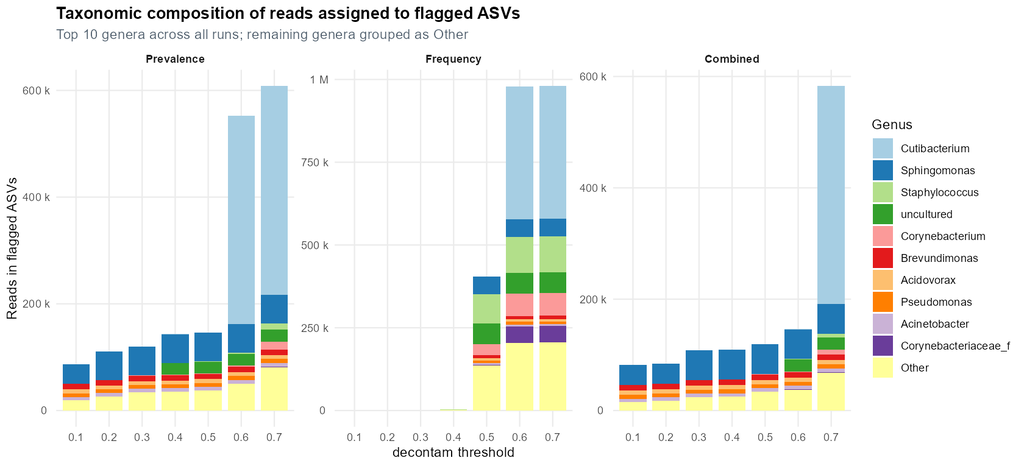

Taxonomic composition is read-weighted; a genus can dominate because one or a few abundant ASVs are flagged.

### Top five flagged genera per run

| Method | Threshold | Genus | Flagged ASVs | Flagged reads |
| --- | --- | --- | --- | --- |
| Prevalence | 0.1 | Sphingomonas | 9 | 36,434 |
| Prevalence | 0.1 | Brevundimonas | 2 | 9,917 |
| Prevalence | 0.1 | Acidovorax | 1 | 7,318 |
| Prevalence | 0.1 | Pseudomonas | 2 | 7,106 |
| Prevalence | 0.1 | Acinetobacter | 4 | 6,497 |
| Prevalence | 0.2 | Sphingomonas | 12 | 53,517 |
| Prevalence | 0.2 | Brevundimonas | 2 | 9,917 |
| Prevalence | 0.2 | Acidovorax | 1 | 7,318 |
| Prevalence | 0.2 | Pseudomonas | 3 | 7,124 |
| Prevalence | 0.2 | Acinetobacter | 5 | 6,500 |
| Prevalence | 0.3 | Sphingomonas | 12 | 53,517 |
| Prevalence | 0.3 | Brevundimonas | 3 | 10,214 |
| Prevalence | 0.3 | Kocuria | 2 | 7,698 |
| Prevalence | 0.3 | Acidovorax | 1 | 7,318 |
| Prevalence | 0.3 | Pseudomonas | 3 | 7,124 |
| Prevalence | 0.4 | Sphingomonas | 13 | 53,733 |
| Prevalence | 0.4 | uncultured | 1 | 21,899 |
| Prevalence | 0.4 | Brevundimonas | 3 | 10,214 |
| Prevalence | 0.4 | Kocuria | 2 | 7,698 |
| Prevalence | 0.4 | Acidovorax | 1 | 7,318 |
| Prevalence | 0.5 | Sphingomonas | 13 | 53,733 |
| Prevalence | 0.5 | uncultured | 1 | 21,899 |
| Prevalence | 0.5 | Brevundimonas | 3 | 10,214 |
| Prevalence | 0.5 | Kocuria | 2 | 7,698 |
| Prevalence | 0.5 | Acidovorax | 1 | 7,318 |
| Prevalence | 0.6 | Cutibacterium | 3 | 391,036 |
| Prevalence | 0.6 | Sphingomonas | 16 | 53,783 |
| Prevalence | 0.6 | uncultured | 9 | 22,115 |
| Prevalence | 0.6 | Brevundimonas | 3 | 10,214 |
| Prevalence | 0.6 | Kocuria | 6 | 7,989 |

[output cut: 71 more lines]

## Complete threshold summary

| Method | Threshold | Flagged ASVs | Retained ASVs | All reads removed (%) | Biological reads removed (%) | Control reads removed (%) |
| --- | --- | --- | --- | --- | --- | --- |
| Prevalence | 0.1 | 61 | 2,047 | 8.5 | 3.266 | 61.666 |
| Prevalence | 0.2 | 90 | 2,018 | 10.953 | 4.72 | 74.269 |
| Prevalence | 0.3 | 96 | 2,012 | 11.807 | 5.597 | 74.891 |
| Prevalence | 0.4 | 104 | 2,004 | 14.133 | 8.092 | 75.492 |
| Prevalence | 0.5 | 107 | 2,001 | 14.39 | 8.356 | 75.678 |
| Prevalence | 0.6 | 339 | 1,769 | 54.46 | 50.868 | 90.958 |
| Prevalence | 0.7 | 562 | 1,546 | 59.906 | 56.85 | 90.958 |
| Frequency | 0.1 | 1 | 2,107 | 0.003 | 0.003 | 0 |
| Frequency | 0.2 | 5 | 2,103 | 0.019 | 0.012 | 0.091 |
| Frequency | 0.3 | 13 | 2,095 | 0.051 | 0.047 | 0.091 |
| Frequency | 0.4 | 33 | 2,075 | 0.312 | 0.326 | 0.17 |
| Frequency | 0.5 | 393 | 1,715 | 39.88 | 36.595 | 73.255 |
| Frequency | 0.6 | 683 | 1,425 | 96.364 | 96.782 | 92.119 |
| Frequency | 0.7 | 704 | 1,404 | 96.541 | 96.971 | 92.177 |
| Combined | 0.1 | 34 | 2,074 | 8.022 | 3.114 | 57.878 |
| Combined | 0.2 | 39 | 2,069 | 8.264 | 3.223 | 59.472 |
| Combined | 0.3 | 62 | 2,046 | 10.61 | 4.587 | 71.793 |
| Combined | 0.4 | 76 | 2,032 | 10.751 | 4.709 | 72.125 |
| Combined | 0.5 | 88 | 2,020 | 11.743 | 5.697 | 73.159 |
| Combined | 0.6 | 117 | 1,991 | 14.382 | 8.568 | 73.444 |
| Combined | 0.7 | 430 | 1,678 | 57.407 | 54.324 | 88.724 |

## ASVs flagged at threshold 0.1

This table contains every ASV flagged by at least one method at the conventional 0.1 threshold, ordered by total reads.

| feature_id | total_reads | biological_reads | control_reads | p_prevalence | p_frequency | p_combined | prevalence_0.1 | frequency_0.1 | combined_0.1 | Phylum | Class | Order | Family | Genus | Species |
| --- | --- | --- | --- | --- | --- | --- | --- | --- | --- | --- | --- | --- | --- | --- | --- |
| 6475007d4c6299318792536d385f164c | 32,677 | 11,406 | 21,271 | 0.04227 | 0.44885 | 0.09572 | Yes | No | Yes | Proteobacteria | Alphaproteobacteria | Sphingomonadales | Sphingomonadaceae | Sphingomonas | Sphingomonas_g |
| 88345f78cecaaa6880139b3ce07b02ab | 7,318 | 2,585 | 4,733 | 0.03999 | 0.42387 | 0.08771 | Yes | No | Yes | Proteobacteria | Gammaproteobacteria | Burkholderiales | Comamonadaceae | Acidovorax | Acidovorax_g |
| 1ebf82770d39e7dea4cdd6525d634ae2 | 7,312 | 2,017 | 5,295 | 0.00871 | 0.4544 | 0.02584 | Yes | No | Yes | Proteobacteria | Alphaproteobacteria | Caulobacterales | Caulobacteraceae | Brevundimonas | Brevundimonas_g |
| 4cf4516cf4c31fdeb7320abe6d620f5f | 5,854 | 1,917 | 3,937 | 0.01874 | 0.44581 | 0.04892 | Yes | No | Yes | Proteobacteria | Gammaproteobacteria | Pseudomonadales | Pseudomonadaceae | Pseudomonas | Pseudomonas_g |
| c0f3e9ab9c5425114f971dee2fbcda67 | 5,620 | 1,849 | 3,771 | 0.0234 | 0.44273 | 0.05856 | Yes | No | Yes | Proteobacteria | Gammaproteobacteria | Pseudomonadales | Moraxellaceae | Acinetobacter | Acinetobacter_g |
| f0ca4c55069212f52e5475a7252bd203 | 4,279 | 1,587 | 2,692 | 0.0234 | 0.43014 | 0.05646 | Yes | No | Yes | Proteobacteria | Gammaproteobacteria | Burkholderiales | Comamonadaceae | Aquabacterium | Aquabacterium_g |
| 597c178a32c8e105554890ac672203a1 | 2,913 | 2,154 | 759 | 0.00011 | 0.4695 | 0.00059 | Yes | No | Yes | Firmicutes | Bacilli | Lactobacillales | Streptococcaceae | Lactococcus | Lactococcus_g |
| f7c74ae8ba237267fafee0b17dd9e25b | 2,605 | 875 | 1,730 | 0.00871 | 0.48105 | 0.02812 | Yes | No | Yes | Proteobacteria | Alphaproteobacteria | Caulobacterales | Caulobacteraceae | Brevundimonas | Brevundimonas_g |
| daaaef75203e565e99ae0771a9444f21 | 1,516 | 565 | 951 | 0.00123 | 0.45793 | 0.00532 | Yes | No | Yes | Proteobacteria | Alphaproteobacteria | Acetobacterales | Acetobacteraceae | Acetobacter | Acetobacter_g |
| eafd5ed5949335dcc9571e96a30c242a | 1,252 | 459 | 793 | 0.00222 | 0.47964 | 0.00904 | Yes | No | Yes | Proteobacteria | Gammaproteobacteria | Pseudomonadales | Pseudomonadaceae | Pseudomonas | Pseudomonas_g |
| db5feda280235363e4c8712675e1bfac | 1,204 | 110 | 1,094 | 0.00025 | 0.47469 | 0.0012 | Yes | No | Yes | Proteobacteria | Alphaproteobacteria | Sphingomonadales | Sphingomonadaceae | Sphingomonas | Sphingomonas_g |
| b94a8e609e84f35c93506768aac4ec3f | 1,091 | 423 | 668 | 0.00167 | 0.4361 | 0.00639 | Yes | No | Yes | Proteobacteria | Alphaproteobacteria | Acetobacterales | Acetobacteraceae | Acetobacter | Acetobacter_g |
| dc48fa77e362e32c1c0cd76272dddec9 | 992 | 264 | 728 | 0.00616 | 0.4556 | 0.01908 | Yes | No | Yes | Proteobacteria | Alphaproteobacteria | Sphingomonadales | Sphingomonadaceae | Sphingomonas | Sphingomonas_g |
| 515173287266f7569f063b717a04424b | 879 | 373 | 506 | 0.0444 | 0.47489 | 0.10543 | Yes | No | No | Proteobacteria | Alphaproteobacteria | Rhizobiales | Rhizobiales_Incertae_Sedis | Phreatobacter | Phreatobacter_g |
| cf9ea686e73af7e1213fb5a0adf1d848 | 767 | 565 | 202 | 0.01944 | 0.52503 | 0.05408 | Yes | No | Yes | Firmicutes | Bacilli | Lactobacillales | Streptococcaceae | Lactococcus | Lactococcus_g |
| 44a942b69a980b0f71708f39677e0fab | 764 | 325 | 439 | 0.00123 | 0.40394 | 0.0045 | Yes | No | Yes | Patescibacteria | Saccharimonadia | Saccharimonadales | Saccharimonadaceae | Saccharimonadaceae | Saccharimonadaceae_g |
| b5a1790a016ebf58cd078a0402c96bb1 | 756 | 105 | 651 | 0.0467 | 0.46765 | 0.12034 | Yes | No | No | Proteobacteria | Alphaproteobacteria | Acetobacterales | Acetobacteraceae | Acetobacter | Acetobacter_g |
| 19efac48457c44e44de9dee0a284c57e | 663 | 178 | 485 | 0.00647 | 0.44699 | 0.01884 | Yes | No | Yes | Proteobacteria | Gammaproteobacteria | Pseudomonadales | Moraxellaceae | Acinetobacter | Acinetobacter_g |
| 09fa7968bafe83eb2e527701f26035de | 654 | 177 | 477 | 0.00616 | 0.46269 | 0.0212 | Yes | No | Yes | Proteobacteria | Alphaproteobacteria | Sphingomonadales | Sphingomonadaceae | Sphingomonadaceae_f | Sphingomonadaceae_f |
| 07651569b905138282e1e180aed417da | 620 | 139 | 481 | 0.00616 | 0.44914 | 0.01835 | Yes | No | Yes | Proteobacteria | Gammaproteobacteria | Burkholderiales | Oxalobacteraceae | Massilia | Massilia_g |
| aeea6b40db276dd7ca8b48feb8496324 | 475 | 343 | 132 | 0.0444 | 0.48288 | 0.10634 | Yes | No | No | Deinococcota | Deinococci | Thermales | Thermaceae | Thermus | Thermus_g |
| ded1e7564ed73226b40751b3380f6e08 | 440 | 87 | 353 | 0.00183 | 0.45806 | 0.00715 | Yes | No | Yes | Proteobacteria | Alphaproteobacteria | Sphingomonadales | Sphingomonadaceae | Sphingomonas | Sphingomonas_g |
| 0d223446a6bb0a4f2b01838ac7764ceb | 430 | 247 | 183 | 0.0349 | 0.503 | 0.09166 | Yes | No | Yes | Deinococcota | Deinococci | Thermales | Thermaceae | Thermus | Thermus_g |
| 2c8da51102c5b78996222aa2df8d4f57 | 411 | 56 | 355 | 0.00359 | 0.48712 | 0.00929 | Yes | No | Yes | Proteobacteria | Alphaproteobacteria | Sphingomonadales | Sphingomonadaceae | Sphingomonas | Sphingomonas_g |
| f0651edc7d0cd84e349041f3dad6d48e | 384 | 84 | 300 | 0.00183 | 0.50608 | 0.00733 | Yes | No | Yes | Proteobacteria | Alphaproteobacteria | Sphingomonadales | Sphingomonadaceae | Sphingomonadaceae_f | Sphingomonadaceae_f |
| 70eeb5c7a74ed6b401b74b47e53b5c6e | 348 | 174 | 174 | 0.02674 | 0.45348 | 0.06673 | Yes | No | Yes | Firmicutes | Bacilli | Lactobacillales | Carnobacteriaceae | Atopostipes | Atopostipes_g |
| 1cbda894755e11f49abb45473b87fa68 | 316 | 154 | 162 | 0.08362 | 0.50464 | 0.18313 | Yes | No | No | Proteobacteria | Gammaproteobacteria | Pseudomonadales | Moraxellaceae | Enhydrobacter | Enhydrobacter_g |
| 3a6294eb3d425bab566e180ea33b5d1c | 293 | 126 | 167 | 0.00025 | 0.51514 | 0.00125 | Yes | No | Yes | Proteobacteria | Gammaproteobacteria | Pseudomonadales | Moraxellaceae | Enhydrobacter | Enhydrobacter_g |
| bc33c20af143399af538f97b087424c3 | 248 | 0 | 248 | 0.00019 | 0.52578 |  | Yes | No | No | Proteobacteria | Alphaproteobacteria | Sphingomonadales | Sphingomonadaceae | Sphingomonas | Sphingomonas_g |
| 1911a3c851ef3d9332858d8a162a1562 | 224 | 23 | 201 | 0.00075 | 0.47175 |  | Yes | No | No | Proteobacteria | Alphaproteobacteria | Sphingomonadales | Sphingomonadaceae | Sphingomonas | Sphingomonas_g |
| d6011383b67fbead40650dfd2f7d0946 | 213 | 70 | 143 | 0.00991 | 0.48536 |  | Yes | No | No | Proteobacteria | Gammaproteobacteria | Burkholderiales | Oxalobacteraceae | Massilia | Massilia_g |
| 0f257eb6554772452f4dd12919b5ea5c | 180 | 65 | 115 | 0.01944 | 0.46939 | 0.04185 | Yes | No | Yes | Proteobacteria | Alphaproteobacteria | Sphingomonadales | Sphingomonadaceae | Sphingomonadaceae_f | Sphingomonadaceae_f |
| bdcd181905b312e4ec460df1ed422fcc | 157 | 34 | 123 | 0.09091 | 0.48276 |  | Yes | No | No | Firmicutes | Bacilli | Lactobacillales | Carnobacteriaceae | Atopostipes | Atopostipes_g |
| 83f46afc883880902be3eb1e92d781a4 | 152 | 40 | 112 | 0.09091 | 0.5 |  | Yes | No | No | Proteobacteria | Alphaproteobacteria | Sphingomonadales | Sphingomonadaceae | Sphingobium | Sphingobium_g |
| 7bee88dca1fbc5e28ab85fcab87f145c | 150 | 5 | 145 | 0.00991 | 0.48051 |  | Yes | No | No | Proteobacteria | Alphaproteobacteria | Rhizobiales | Beijerinckiaceae | Methylobacterium-Methylorubrum | Methylobacterium-Methylorubrum_g |
| 8ada78492f809c50ddca39071a1f2d33 | 146 | 18 | 128 | 0.09091 | 0.48864 |  | Yes | No | No | Firmicutes | Bacilli | Staphylococcales | Staphylococcaceae | Staphylococcus | Staphylococcus_g |
| b29c8550b6743108ebda7f81af92a068 | 145 | 18 | 127 | 0.01944 | 0.45765 | 0.05683 | Yes | No | Yes | Proteobacteria | Alphaproteobacteria | Acetobacterales | Acetobacteraceae | Acetobacter | Acetobacter_g |
| 83df293667c11dd7ccebd05bb943a3f4 | 142 | 103 | 39 | 0.00329 | 0.53179 | 0.01287 | Yes | No | Yes | Proteobacteria | Alphaproteobacteria | Sphingomonadales | Sphingomonadaceae | Sphingomonas | Sphingomonas_g |
| 3796cea684bec78d8a792f6e55722ecf | 129 | 21 | 108 | 0.03176 | 0.46728 | 0.0847 | Yes | No | Yes | Deinococcota | Deinococci | Thermales | Thermaceae | Thermus | Thermus_g |
| fbf91904c477c277ba71de6685742761 | 116 | 0 | 116 | 0.00337 | 0.4516 |  | Yes | No | No | Proteobacteria | Gammaproteobacteria | Pseudomonadales | Moraxellaceae | Acinetobacter | Acinetobacter_g |
| dd9a2c01f344e41156e03327c89679f6 | 113 | 0 | 113 | 0.00337 | 0.50284 |  | Yes | No | No | Deinococcota | Deinococci | Thermales | Thermaceae | Thermus | Thermus_g |
| 4678e76b974c53bbd520e17ba70f7e35 | 111 | 58 | 53 | 0.09091 | 0.65933 |  | Yes | No | No | Firmicutes | Clostridia | Peptostreptococcales-Tissierellales | Family_XI | Finegoldia | Finegoldia_g |
| 57b856d2ec363466476d1510607da112 | 109 | 21 | 88 | 0.09091 | 0.46617 |  | Yes | No | No | Proteobacteria | Alphaproteobacteria | Acetobacterales | Acetobacteraceae | Gluconobacter | Gluconobacter_g |
| 16c7937724ed5bbcc657caae1049b378 | 98 | 35 | 63 | 0.00616 | 0.50117 | 0.02287 | Yes | No | Yes | Deinococcota | Deinococci | Thermales | Thermaceae | Thermus | Thermus_g |
| 3c3534c7e92c582ad869dbc8030c4476 | 98 | 0 | 98 | 0.00337 | 0.5 |  | Yes | No | No | Proteobacteria | Gammaproteobacteria | Burkholderiales | Comamonadaceae | Delftia | Delftia_g |
| f687a9c40e82d3510c69f07e7dc29de2 | 98 | 37 | 61 | 0.00359 | 0.50543 | 0.01265 | Yes | No | Yes | Proteobacteria | Gammaproteobacteria | Pseudomonadales | Moraxellaceae | Acinetobacter | Acinetobacter_g |
| 926700c83bd1d7bda75cc8b4abb7d70f | 96 | 30 | 66 | 0.09091 | 0.10953 |  | Yes | No | No | Proteobacteria | Alphaproteobacteria | Sphingomonadales | Sphingomonadaceae | Sphingomonas | Sphingomonas_g |
| b1d400141daf92f660848d86a4555233 | 93 | 57 | 36 | 0.00222 | 0.5035 | 0.00869 | Yes | No | Yes | Proteobacteria | Alphaproteobacteria | Sphingomonadales | Sphingomonadaceae | Sphingomonadaceae_f | Sphingomonadaceae_f |
| 025e519fdc62aba6f39ab17117a65353 | 88 | 46 | 42 | 0.03176 | 0.47533 | 0.07656 | Yes | No | Yes | Deinococcota | Deinococci | Thermales | Thermaceae | Thermus | Thermus_g |
| 3941adc1fe9b742248db0935aef3cc16 | 80 | 12 | 68 | 0.00991 | 0.49331 |  | Yes | No | No | Deinococcota | Deinococci | Thermales | Thermaceae | Thermus | Thermus_g |
| f879993ce3b93e9a4fa11a03b7d67bda | 79 | 28 | 51 | 0.09091 | 0.46048 |  | Yes | No | No | Proteobacteria | Alphaproteobacteria | Sphingomonadales | Sphingomonadaceae | Novosphingobium | Novosphingobium_g |
| f3d9a01f32e11cf7046bf15e69696067 | 65 | 0 | 65 | 0.00337 | 0.52249 |  | Yes | No | No | Deinococcota | Deinococci | Thermales | Thermaceae | Thermus | Thermus_g |
| b92f152681dbc5fe0a3758d6eb8a5352 | 60 | 30 | 30 | 0.09091 | 0.70501 |  | Yes | No | No | Firmicutes | Bacilli | Lactobacillales | Streptococcaceae | Streptococcus | Streptococcus_g |
| 8df42276596c8da9152a47542191421f | 49 | 12 | 37 | 0.13617 | 0.47081 | 0.07786 | No | No | Yes | Proteobacteria | Gammaproteobacteria | Burkholderiales | Rhodocyclaceae | Dechloromonas | Dechloromonas_g |
| 17932ac3c52ad0a1130730fccdb1b9ed | 47 | 15 | 32 | 0.09091 | 0.51397 |  | Yes | No | No | Actinobacteriota | Actinobacteria | Corynebacteriales | Corynebacteriaceae | Corynebacterium | Corynebacterium_g |
| 28d4804cd510461cd1fc4f3f7f711287 | 43 | 6 | 37 | 0.09091 | 0.48288 |  | Yes | No | No | Proteobacteria | Alphaproteobacteria | Acetobacterales | Acetobacteraceae | Acetobacter | Acetobacter_g |
| 37e5eaf84ef571ef522201ea47549439 | 43 | 15 | 28 | 0.09091 | 0.51705 |  | Yes | No | No | Cyanobacteria | Vampirivibrionia | Obscuribacterales | Obscuribacteraceae | Candidatus_Obscuribacter | Candidatus_Obscuribacter_g |
| ef7e7ee4a37d9c328b90f87d55d699a8 | 40 | 23 | 17 | 0.09091 | 0.10183 |  | Yes | No | No | Proteobacteria | Gammaproteobacteria | Burkholderiales | Comamonadaceae | Variovorax | Variovorax_g |
| 7d181e8903232b80932beb1eef01c94f | 39 | 6 | 33 | 0.09091 | 0.46807 |  | Yes | No | No | Deinococcota | Deinococci | Thermales | Thermaceae | Thermus | Thermus_g |
| 84cb958bc116ba8c20da3ac589ca6101 | 31 | 0 | 31 | 0.00337 | 0.36472 |  | Yes | No | No | Deinococcota | Deinococci | Thermales | Thermaceae | Thermus | Thermus_g |
| 3e40912777b69502473bead5d31f868e | 30 | 30 | 0 | 0.58754 | 0.0673 | 0.16728 | No | Yes | No | Proteobacteria | Alphaproteobacteria | Rhodobacterales | Rhodobacteraceae | Paracoccus | Paracoccus_g |
| 6b7e98a41e4c765301401fc43310d8b1 | 27 | 25 | 2 | 0.01944 | 0.50205 | 0.04513 | Yes | No | Yes | Deinococcota | Deinococci | Thermales | Thermaceae | Thermus | Thermus_g |
| e54b60533120912c2eb5b6ceb7d45eb4 | 17 | 10 | 7 | 0.09091 | 0.5 |  | Yes | No | No | Proteobacteria | Gammaproteobacteria | Burkholderiales | Comamonadaceae | Alicycliphilus | Alicycliphilus_g |

## Reproducibility notes

- Input: `phy_F270R240_260812_v3.rds` (55 samples, 2,108 ASVs).
- Concentration: `Original_QC_Conc_ng_uL` from the supplied sequencing metadata.
- Negative controls: the five v3 rows with missing `control_status`, cross-checked against the Excel `Negative control` category.
- For every method and threshold, the report verified that detailed p-values reproduce the direct logical result returned by `decontam::isContaminant()`.
- Missing p-values are not classified as contaminants. Coverage: prevalence 715/2108, frequency 715/2108, combined 691/2108.